# INSTRUCTIONS

- This is a group assignment.
- Submit your answer digitally as two files through Moodle:
  - An R markdown file (extension **Rmd**). Use the template provided to you and provide your answers (both code and text) below each question.
  - An **HTML** file “knitted” by RStudio including all the results and plots. More details on how to create these files will be provided in class on week 3.
- Follow the Style Guide (available on Moodle). You can be penalized on up to 20% in each question for which you do not follow the Style Guide.
- Questions regarding the assignment should be posted exclusively on the respective discussion forum on Moodle.
- **Deadline:** 25 February 2024 23:59

**Warning:** The detection of any form of plagiarism in your work means the assignment will be graded with ZERO points.

# Movie Networks

We are interested in assessing what are the most important movies in the decade 2010-2019. We will use different strategies to do so. First, we will load and prepare the data.

## Load and prepare the data

The first step is to load and prepare the movie data. The following instructions perform some routine data preparation operations. Each set of instructions is preceded by a comment explaining the procedure. Run the code below and try to understand each line of code as you might need to perform some changes.

Load the data that you prepared using the instructions below. As mentioned in the comments, you can start from this line if you have previously saved these data.

## Questions (`data.table`) `[7 points]`

This set of questions require that you know how to manipulate a `data.table`. Answer each of the following questions below. Include all the code you created/used in your answer.

1. What is the total amount of movies in the `dt.movie.actor` dataset? `[1 point]`

```
## [1] 368522
```

The total amount of movies in the `dt.movie.actor` dataset is 368522.

2. List the actors from the movie `"Fight Club (1999)"`. List the actors from the movie `"Se7en (1995)"`. `[1 point]`

Actors from Fight Club:

```
##                     actor
## 1:     Brad Pitt (b.1963)
## 2:     Meat Loaf (b.1947)
## 3: Edward Norton (b.1969)
## 4:  Zach Grenier (b.1954)
```

Actors from Se7en:

```
##                           actor
## 1:           Brad Pitt (b.1963)
## 2:      Morgan Freeman (b.1937)
## 3:        Kevin Spacey (b.1959)
## 4: Andrew Kevin Walker (b.1964)
```

3. Which actors participated on both movies? Hint: The function `intersect` calculates the intersection of two sets. `[1 point]`

```
## [1] "Brad Pitt (b.1963)"
```

Brad Pitt participated in both Fight Club and Se7en.

4. In which movies did Brad Pitt (b.1963) and George Clooney (b.1961) star together? `[1 point]`

George Clooney and Brad Pitt starred together in the following movies:

```
## [1] "Ocean's Eleven (2001)"     "Ocean's Twelve (2004)"
## [3] "Ocean's Thirteen (2007)"   "Burn After Reading (2008)"
```

5. Create a table that shows the number of movies released per year. This table should include three columns: `year`, `n_movies`, and `csum_n_movies`. The first column should contain the year, the second the number of movies in that year, and the third, the number of movies released since the first year in the data and up to the year in that line. Tip: Use the function `cumsum` and check if the amount in the last year is the same as the total number of movies in question 1. `[1 point]`

Number of movies released per year:

```
##      year n_movies csum_n_movies
##   1: 1894        1             1
##   2: 1899        1             2
##   3: 1900        1             3
##   4: 1905        2             5
##   5: 1906        4             9
##  ---
## 114: 2015    10731        322844
## 115: 2016    11409        334253
## 116: 2017    11667        345920
## 117: 2018    11775        357695
## 118: 2019    10827        368522
```

6. Which actor/actress has starred in the most movies across all data? After (and including) 2000, which year has the most movie participations by a single actor/actress? Who is that actor/actress? What do these two actors/actresses have in common? `[1 point]`

```
##                    actor   N
## 1: Brahmanandam (b.1956) 804
```

Brahmanandam has starred in the most movies across all data.

```
##           actor year  n
## 1: Anil Nagrath 2001 35
```

After (and including) 2000, the year that had the most movie participations by a single actor/actress was 2001, and the actor Anil Nagrath with 35 appearances.

```
## character(0)
```

Anil Nagrath and Brahmanandam didn’t work in any film together. But they are both Indian, so they share that in common.

7. Consider only the 10% most popular movies (by votes) in the decade 2010-2019. List the top 10 actors that starred in the most movies in the decade. Which year(s) has/have the most movie participations by a single actor? Hint: you can use the function `quantile` to find how many votes does the movie in percentile 90 have. `[1 point]`

```
##                          actor count
##  1:      Akshay Kumar (b.1967)    36
##  2:      Nicolas Cage (b.1964)    33
##  3:      James Franco (b.1978)    26
##  4:    Robert De Niro (b.1943)    24
##  5:      Bruce Willis (b.1955)    24
##  6:     Anna Kendrick (b.1985)    24
##  7:       John Cusack (b.1966)    23
##  8: Samuel L. Jackson (b.1948)    23
##  9:       Liam Neeson (b.1952)    22
## 10:        Ajay Devgn (b.1969)    22
```

```
##                   actor year n
## 1: Liam Neeson (b.1952) 2014 7
```

Liam Neeson had the most appearances in 2014, being 7.

## Questions (`ggplot2`) `[3 points]`

1. Plot a histogram with the number of movies per year. Which patterns do you observe? Is there anything strange? `[1 point]`

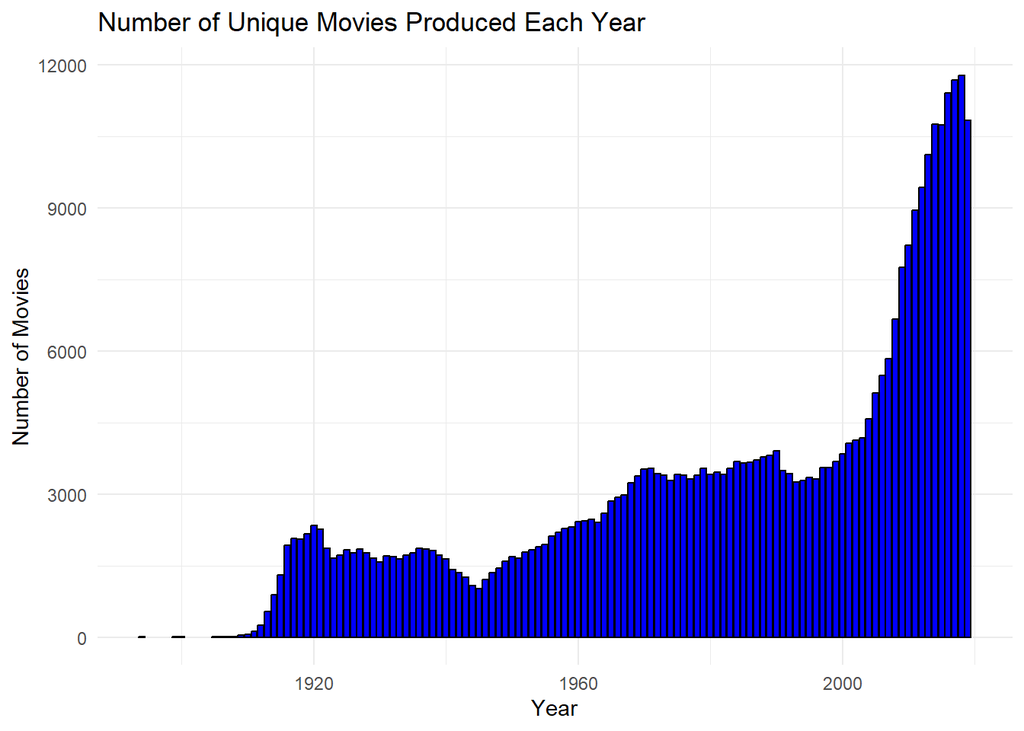

2. Plot a histogram that represents the distribution of number of IMDb votes per movie. The x-axis should represent the number of votes and the y-axis should represent how many movies have x number of votes. Which patterns do you observe? `[1 point]`

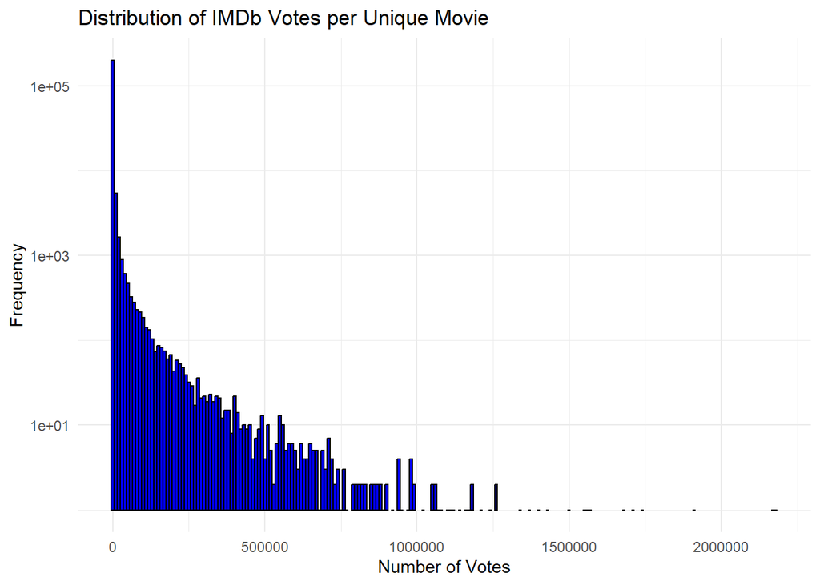

3. Plot a histogram that represents the distribution of the number of actors per movie. The x-axis should represent the number of actors and the y-axis should represent how many movies have x number of actors. Describe your findings. `[1 point]`

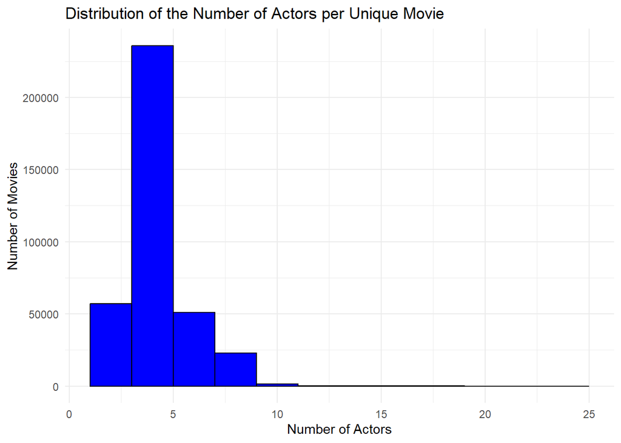

## Questions (`igraph`) `[10 points]`

1. From this question onwards, and until the end of the assignment, focus only on the actors that participated on the top 50 most popular movies from the 2010-2019 decade (by number of votes). Load the `igraph` package and create a bipartite graph in which the edges correspond to actors’ participation in movies. How many movie participations exist? `[1 point]`

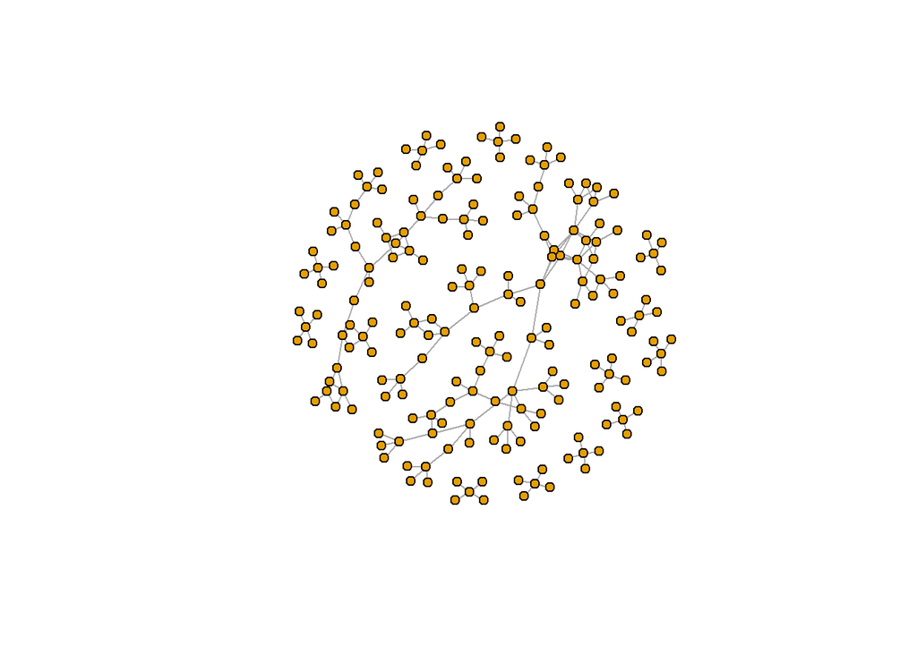

```
## [1] 200
```

Number of participations is 200.

2. Create a graph in which two movies are connected to each other if they have at least one actor in common. Calculate the degree centrality for each of the movies, and remove movies with no connections to other movies. Hint: the function `induced.subgraph` allows the creation of graphs with only a subset of the vertices. Calculate the following additional centrality measures for each of these movies: `[2 points]`
   - Closeness centrality
   - Betweenness centrality
   - Eigenvector centrality

```
## IGRAPH 0303db8 UNW- 38 80 --
## + attr: name (v/c), weight (e/n)
```

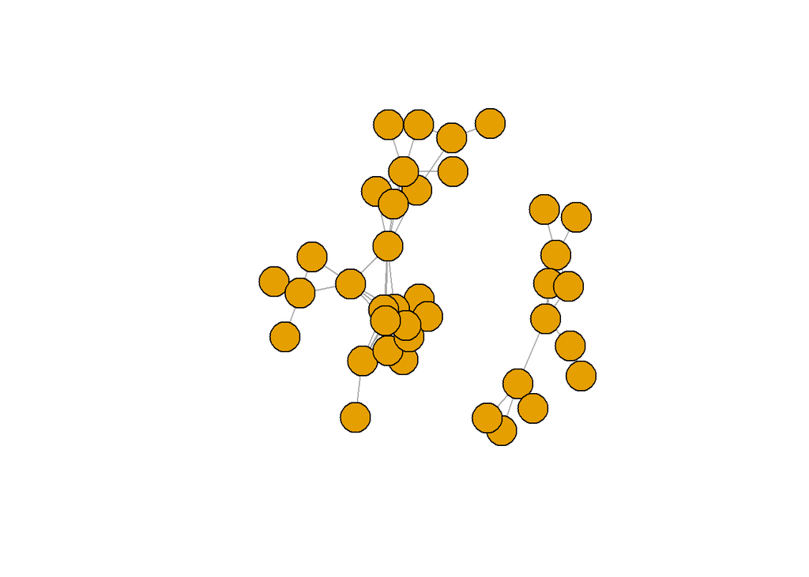

```
##                                                                                               Movie
## World War Z (2013)                                                               World War Z (2013)
## 12 Years a Slave (2013)                                                     12 Years a Slave (2013)
## X-Men: First Class (2011)                                                 X-Men: First Class (2011)
## Silver Linings Playbook (2012)                                       Silver Linings Playbook (2012)
## Joker (2019)                                                                           Joker (2019)
## The Wolf of Wall Street (2013)                                       The Wolf of Wall Street (2013)
## Shutter Island (2010)                                                         Shutter Island (2010)
## Inception (2010)                                                                   Inception (2010)
## The Revenant (2015)                                                             The Revenant (2015)
## Django Unchained (2012)                                                     Django Unchained (2012)
## Thor (2011)                                                                             Thor (2011)
## Captain America: The First Avenger (2011)                 Captain America: The First Avenger (2011)
## Captain America: The Winter Soldier (2014)               Captain America: The Winter Soldier (2014)
## Man of Steel (2013)                                                             Man of Steel (2013)
## Interstellar (2014)                                                             Interstellar (2014)
## The Dark Knight Rises (2012)                                           The Dark Knight Rises (2012)
## Black Swan (2010)                                                                 Black Swan (2010)
## Mad Max: Fury Road (2015)                                                 Mad Max: Fury Road (2015)
## Gone Girl (2014)                                                                   Gone Girl (2014)
## Batman v Superman: Dawn of Justice (2016)                 Batman v Superman: Dawn of Justice (2016)
## Iron Man 2 (2010)                                                                 Iron Man 2 (2010)
## Iron Man 3 (2013)                                                                 Iron Man 3 (2013)
## The Martian (2015)                                                               The Martian (2015)
## The Avengers (2012)                                                             The Avengers (2012)
## Avengers: Age of Ultron (2015)                                       Avengers: Age of Ultron (2015)
## Captain America: Civil War (2016)                                 Captain America: Civil War (2016)
## Avengers: Infinity War (2018)                                         Avengers: Infinity War (2018)
## Avengers: Endgame (2019)                                                   Avengers: Endgame (2019)
## Now You See Me (2013)                                                         Now You See Me (2013)
## The Hunger Games: Catching Fire (2013)                       The Hunger Games: Catching Fire (2013)
## X-Men: Days of Future Past (2014)                                 X-Men: Days of Future Past (2014)
## Logan (2017)                                                                           Logan (2017)
## The Hunger Games (2012)                                                     The Hunger Games (2012)
## Guardians of the Galaxy (2014)                                       Guardians of the Galaxy (2014)
## The Hobbit: An Unexpected Journey (2012)                   The Hobbit: An Unexpected Journey (2012)
## The Hobbit: The Desolation of Smaug (2013)               The Hobbit: The Desolation of Smaug (2013)
## The Social Network (2010)                                                 The Social Network (2010)
## Star Wars: Episode VII - The Force Awakens (2015) Star Wars: Episode VII - The Force Awakens (2015)
##                                                     Closeness Betweenness
```

[output cut: 62 more lines]

```
## The Avengers (2012)                               7.811770e-01
## Avengers: Age of Ultron (2015)                    1.000000e+00
## Captain America: Civil War (2016)                 7.811770e-01
## Avengers: Infinity War (2018)                     1.000000e+00
## Avengers: Endgame (2019)                          1.000000e+00
## Now You See Me (2013)                             2.412304e-01
## The Hunger Games: Catching Fire (2013)            6.322597e-17
## X-Men: Days of Future Past (2014)                 3.161299e-17
## Logan (2017)                                      1.580649e-17
## The Hunger Games (2012)                           9.483896e-17
## Guardians of the Galaxy (2014)                    7.903246e-18
## The Hobbit: An Unexpected Journey (2012)          9.483896e-17
## The Hobbit: The Desolation of Smaug (2013)        0.000000e+00
## The Social Network (2010)                         1.916538e-02
## Star Wars: Episode VII - The Force Awakens (2015) 1.727212e-03
```

3. For each centrality measure, list the top 20 movies with highest centrality. How do you interpret the outcomes? `[2 points]`

Top 20 movies by closeness centrality:

```
##                                                                                 Movie
## X-Men: First Class (2011)                                   X-Men: First Class (2011)
## Silver Linings Playbook (2012)                         Silver Linings Playbook (2012)
## X-Men: Days of Future Past (2014)                   X-Men: Days of Future Past (2014)
## The Hunger Games: Catching Fire (2013)         The Hunger Games: Catching Fire (2013)
## The Hunger Games (2012)                                       The Hunger Games (2012)
## 12 Years a Slave (2013)                                       12 Years a Slave (2013)
## Joker (2019)                                                             Joker (2019)
## Guardians of the Galaxy (2014)                         Guardians of the Galaxy (2014)
## The Hobbit: An Unexpected Journey (2012)     The Hobbit: An Unexpected Journey (2012)
## The Hobbit: The Desolation of Smaug (2013) The Hobbit: The Desolation of Smaug (2013)
## World War Z (2013)                                                 World War Z (2013)
## Logan (2017)                                                             Logan (2017)
## Shutter Island (2010)                                           Shutter Island (2010)
## Avengers: Age of Ultron (2015)                         Avengers: Age of Ultron (2015)
## Avengers: Infinity War (2018)                           Avengers: Infinity War (2018)
## Avengers: Endgame (2019)                                     Avengers: Endgame (2019)
## Now You See Me (2013)                                           Now You See Me (2013)
## The Revenant (2015)                                               The Revenant (2015)
## The Wolf of Wall Street (2013)                         The Wolf of Wall Street (2013)
## Inception (2010)                                                     Inception (2010)
##                                             Closeness Betweenness  Eigenvector
## X-Men: First Class (2011)                  0.05555556    38.50000 9.483896e-17
## Silver Linings Playbook (2012)             0.04545455    19.50000 3.161299e-17
## X-Men: Days of Future Past (2014)          0.04545455    27.00000 3.161299e-17
## The Hunger Games: Catching Fire (2013)     0.04000000     0.00000 6.322597e-17
## The Hunger Games (2012)                    0.04000000     0.00000 9.483896e-17
## 12 Years a Slave (2013)                    0.03846154    10.00000 3.161299e-17
## Joker (2019)                               0.03125000     0.00000 7.903246e-18
## Guardians of the Galaxy (2014)             0.03125000     0.00000 7.903246e-18
## The Hobbit: An Unexpected Journey (2012)   0.03125000     0.00000 9.483896e-17
## The Hobbit: The Desolation of Smaug (2013) 0.03125000     0.00000 0.000000e+00
## World War Z (2013)                         0.02777778     0.00000 2.370974e-17
## Logan (2017)                               0.02380952     0.00000 1.580649e-17
## Shutter Island (2010)                      0.02040816   144.42857 2.449395e-01
## Avengers: Age of Ultron (2015)             0.01923077    45.51667 1.000000e+00
## Avengers: Infinity War (2018)              0.01923077    45.51667 1.000000e+00
## Avengers: Endgame (2019)                   0.01923077    45.51667 1.000000e+00
## Now You See Me (2013)                      0.01851852    84.42857 2.412304e-01
## The Revenant (2015)                        0.01612903    63.50000 2.351178e-02
## The Wolf of Wall Street (2013)             0.01587302    40.00000 2.325598e-02
## Inception (2010)                           0.01538462     0.00000 2.312831e-02
```

Top 20 movies by betweenness centrality:

```
##                                                                               Movie
## Shutter Island (2010)                                         Shutter Island (2010)
## Now You See Me (2013)                                         Now You See Me (2013)
## The Revenant (2015)                                             The Revenant (2015)
## Batman v Superman: Dawn of Justice (2016) Batman v Superman: Dawn of Justice (2016)
## Avengers: Age of Ultron (2015)                       Avengers: Age of Ultron (2015)
## Avengers: Infinity War (2018)                         Avengers: Infinity War (2018)
## Avengers: Endgame (2019)                                   Avengers: Endgame (2019)
## The Wolf of Wall Street (2013)                       The Wolf of Wall Street (2013)
## X-Men: First Class (2011)                                 X-Men: First Class (2011)
## X-Men: Days of Future Past (2014)                 X-Men: Days of Future Past (2014)
## Interstellar (2014)                                             Interstellar (2014)
## Thor (2011)                                                             Thor (2011)
## Silver Linings Playbook (2012)                       Silver Linings Playbook (2012)
## Captain America: The First Avenger (2011) Captain America: The First Avenger (2011)
## Iron Man 2 (2010)                                                 Iron Man 2 (2010)
## Iron Man 3 (2013)                                                 Iron Man 3 (2013)
## 12 Years a Slave (2013)                                     12 Years a Slave (2013)
## The Dark Knight Rises (2012)                           The Dark Knight Rises (2012)
## The Avengers (2012)                                             The Avengers (2012)
## Captain America: Civil War (2016)                 Captain America: Civil War (2016)
##                                            Closeness Betweenness  Eigenvector
## Shutter Island (2010)                     0.02040816   144.42857 2.449395e-01
## Now You See Me (2013)                     0.01851852    84.42857 2.412304e-01
## The Revenant (2015)                       0.01612903    63.50000 2.351178e-02
## Batman v Superman: Dawn of Justice (2016) 0.01369863    47.00000 1.965956e-02
## Avengers: Age of Ultron (2015)            0.01923077    45.51667 1.000000e+00
## Avengers: Infinity War (2018)             0.01923077    45.51667 1.000000e+00
## Avengers: Endgame (2019)                  0.01923077    45.51667 1.000000e+00
## The Wolf of Wall Street (2013)            0.01587302    40.00000 2.325598e-02
## X-Men: First Class (2011)                 0.05555556    38.50000 9.483896e-17
## X-Men: Days of Future Past (2014)         0.04545455    27.00000 3.161299e-17
## Interstellar (2014)                       0.01219512    24.50000 1.865554e-03
## Thor (2011)                               0.01428571    24.42857 2.215804e-01
## Silver Linings Playbook (2012)            0.04545455    19.50000 3.161299e-17
## Captain America: The First Avenger (2011) 0.01470588    10.76190 4.101157e-01
## Iron Man 2 (2010)                         0.01470588    10.76190 4.299013e-01
## Iron Man 3 (2013)                         0.01470588    10.76190 4.299013e-01
## 12 Years a Slave (2013)                   0.03846154    10.00000 3.161299e-17
## The Dark Knight Rises (2012)              0.01234568     4.00000 2.001946e-03
## The Avengers (2012)                       0.01149425     0.60000 7.811770e-01
## Captain America: Civil War (2016)         0.01149425     0.60000 7.811770e-01
```

Top 20 movies by eigenvector centrality:

```
##                                                                                 Movie
## Avengers: Infinity War (2018)                           Avengers: Infinity War (2018)
## Avengers: Endgame (2019)                                     Avengers: Endgame (2019)
## Avengers: Age of Ultron (2015)                         Avengers: Age of Ultron (2015)
## The Avengers (2012)                                               The Avengers (2012)
## Captain America: Civil War (2016)                   Captain America: Civil War (2016)
## Captain America: The Winter Soldier (2014) Captain America: The Winter Soldier (2014)
## Iron Man 2 (2010)                                                   Iron Man 2 (2010)
## Iron Man 3 (2013)                                                   Iron Man 3 (2013)
## Captain America: The First Avenger (2011)   Captain America: The First Avenger (2011)
## Shutter Island (2010)                                           Shutter Island (2010)
## Now You See Me (2013)                                           Now You See Me (2013)
## Thor (2011)                                                               Thor (2011)
## The Revenant (2015)                                               The Revenant (2015)
## The Wolf of Wall Street (2013)                         The Wolf of Wall Street (2013)
## Inception (2010)                                                     Inception (2010)
## Django Unchained (2012)                                       Django Unchained (2012)
## Batman v Superman: Dawn of Justice (2016)   Batman v Superman: Dawn of Justice (2016)
## The Social Network (2010)                                   The Social Network (2010)
## Black Swan (2010)                                                   Black Swan (2010)
## Man of Steel (2013)                                               Man of Steel (2013)
##                                              Closeness Betweenness Eigenvector
## Avengers: Infinity War (2018)              0.019230769  45.5166667 1.000000000
## Avengers: Endgame (2019)                   0.019230769  45.5166667 1.000000000
## Avengers: Age of Ultron (2015)             0.019230769  45.5166667 1.000000000
## The Avengers (2012)                        0.011494253   0.6000000 0.781177032
## Captain America: Civil War (2016)          0.011494253   0.6000000 0.781177032
## Captain America: The Winter Soldier (2014) 0.014285714   0.4285714 0.510186045
## Iron Man 2 (2010)                          0.014705882  10.7619048 0.429901254
## Iron Man 3 (2013)                          0.014705882  10.7619048 0.429901254
## Captain America: The First Avenger (2011)  0.014705882  10.7619048 0.410115731
## Shutter Island (2010)                      0.020408163 144.4285714 0.244939536
## Now You See Me (2013)                      0.018518519  84.4285714 0.241230437
## Thor (2011)                                0.014285714  24.4285714 0.221580439
## The Revenant (2015)                        0.016129032  63.5000000 0.023511780
## The Wolf of Wall Street (2013)             0.015873016  40.0000000 0.023255980
## Inception (2010)                           0.015384615   0.0000000 0.023128313
## Django Unchained (2012)                    0.015384615   0.0000000 0.023128313
## Batman v Superman: Dawn of Justice (2016)  0.013698630  47.0000000 0.019659555
## The Social Network (2010)                  0.013333333   0.0000000 0.019165384
## Black Swan (2010)                          0.010638298   0.0000000 0.016277643
## Man of Steel (2013)                        0.008264463   0.0000000 0.002888443
```

Closeness centrality measures how close a node is to all other nodes in the network, based on the shortest paths. For movies, it can indicate how quickly information (e.g., an actor moving between projects) spreads from that movie to others in the network.

Betweenness centrality measures the extent to which a node lies on paths between other nodes. For movies, a high betweenness centrality indicates a movie that connects many other movies through shared actors, potentially acting as a bridge within the network.

Eigenvector centrality measures a node’s influence based on the number and quality of its connections. For movies, it reflects how well-connected a movie is to other well-connected movies, highlighting films that are central in densely interconnected communities of actors.

4. Calculate the average clustering coefficient for the movies network. `[1 point]`

```
## [1] 0.6551873
```

In the context of a graph that links movies based on shared actors, a clustering coefficient of approximately 0.66 would suggest a relatively high degree of clustering. This could be interpreted as an indication that certain groups of actors tend to work together frequently, leading to a high degree of interconnectedness among the movies they appear in.

5. Choose one movie you like and plot the movie, their direct neighbors and the links among them. What is the clustering coefficient of this movie? Which is the actor with most participations among these (neighbor) movies, but not having participated in the movie itself? `[2 points]`

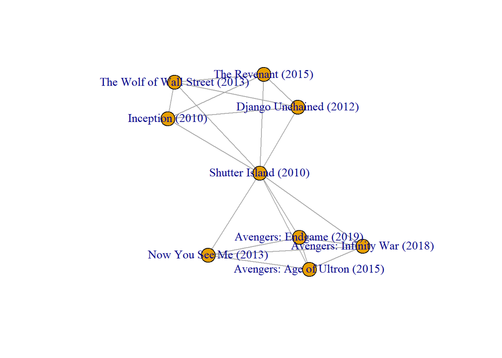

Clustering coefficient of:

```
## Shutter Island (2010)
##             0.4285714
```

The actors/actresses with more participations in neighbour movies but not having participated in Shutter Island are:

```
##                         actor N
## 1: Robert Downey Jr. (b.1965) 3
## 2:       Chris Evans (b.1981) 3
## 3:   Chris Hemsworth (b.1983) 3
```

These results make total sense, since there are 3 movies from the Avengers series present in this graph because of Mark Ruffalo (Hulk character) connection. And so, Robert Downey Jr. is the actor of the character Iron Man, Chris Evans of the character Captain America, and Chris Hemsworth of Thor, all from Avengers.

6. Plot the degree distribution of the movies. How do you compare them with the degree distribution of a random graph? What can be plausible explanations for the observed differences? `[2 points]`

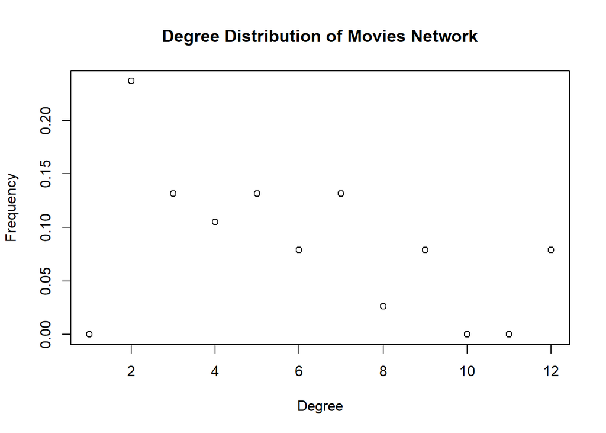

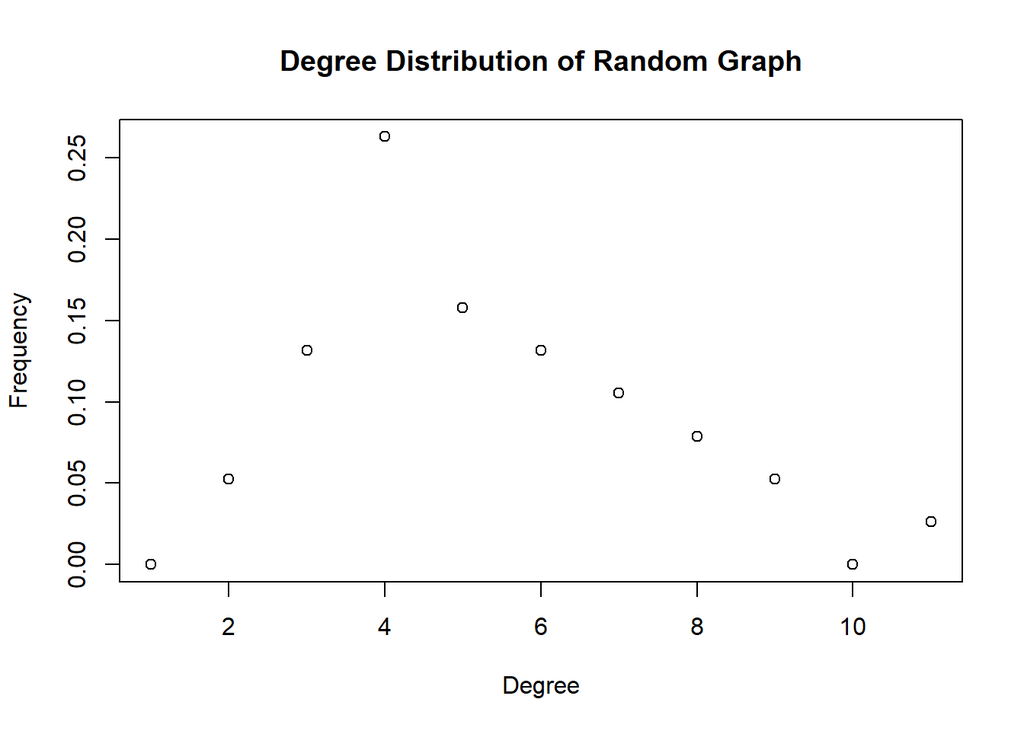